# Incidencias | Departamento de Ciencias Administrativas

## Profesores

A continuación se muestra un análisis simple de las asistencias de profesores de asignatura del departamento de ciencias administrativas y negocios (DCAN) usando el paquete `calendR`. Primeramente se procesan los datos usando los paquetes `dplyr`y `lubridate` con el propósito de generar nuevas columnas (fecha y hora). Es importante mencionar que muchos de los nombres no se encuentran codificados adecuadamente y por tanto se recomienda recodificar el dispositivo para el chequeo de entradas y salidas. La lista de profesores del DCAN son

|  | Profesores | Depto |
| --- | --- | --- |
| 1 | ALFREDO CASTILLO CIRA | CIENCIAS ADMINISTRATIVAS Y NEGOCIOS |
| 2 | CLAUDIA DÍAZ CASILLAS | CIENCIAS ADMINISTRATIVAS Y NEGOCIOS |
| 3 | ENRIQUE ROBERTO PERALTA MAZARIEGO | CIENCIAS ADMINISTRATIVAS Y NEGOCIOS |
| 4 | FABIOLA BETANCOURT OSORIO | CIENCIAS ADMINISTRATIVAS Y NEGOCIOS |
| 5 | FRANCISCO NAHUAT CHIMAL | CIENCIAS ADMINISTRATIVAS Y NEGOCIOS |
| 6 | GERARDO FLORES MARCELO | CIENCIAS ADMINISTRATIVAS Y NEGOCIOS |
| 7 | JORGE LUIS OCOTITLA VÁZQUEZ | CIENCIAS ADMINISTRATIVAS Y NEGOCIOS |
| 8 | LILIANA CITALÁN | CIENCIAS ADMINISTRATIVAS Y NEGOCIOS |
| 9 | LUIS BASULTO SOLIS | CIENCIAS ADMINISTRATIVAS Y NEGOCIOS |
| 10 | MARIO LEORNARDO FERNÁNDEZ UC | CIENCIAS ADMINISTRATIVAS Y NEGOCIOS |

[output cut: 11 more lines]

## ALFREDO CASTILLO CIRA

El profesor Alfredo, de acuerdo a los datos tiene clases los días: lunes, miércoles. De acuerdo a los datos, los días en los cuales el profesor asistió y no asistió se muestran en el siguiente calendario.

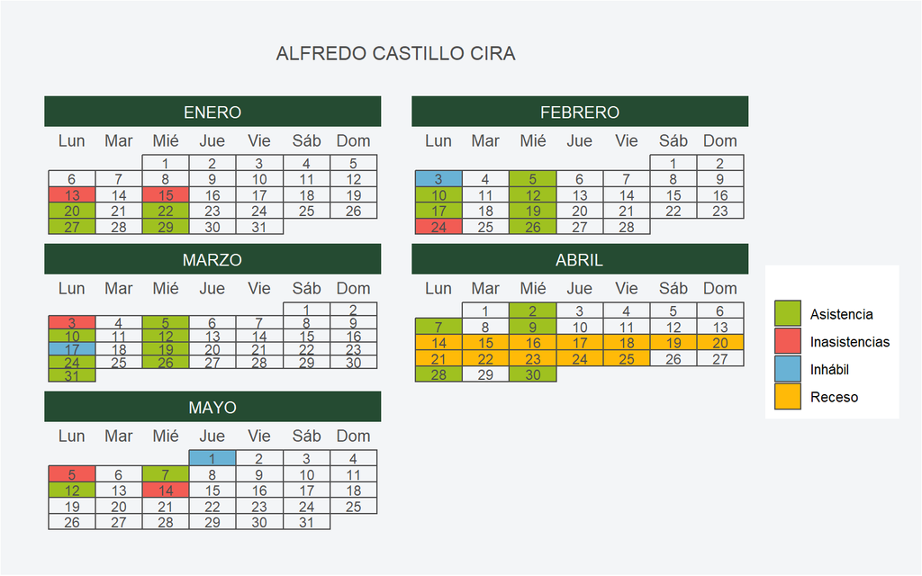

## CLAUDIA EDITH DIAZ CASILLAS

La profesora, de acuerdo a los datos tiene clases los días: lunes, martes, miércoles, jueves. De acuerdo a los datos, los días en los cuales la profesora asistió y no asistió se muestran en el siguiente calendario.

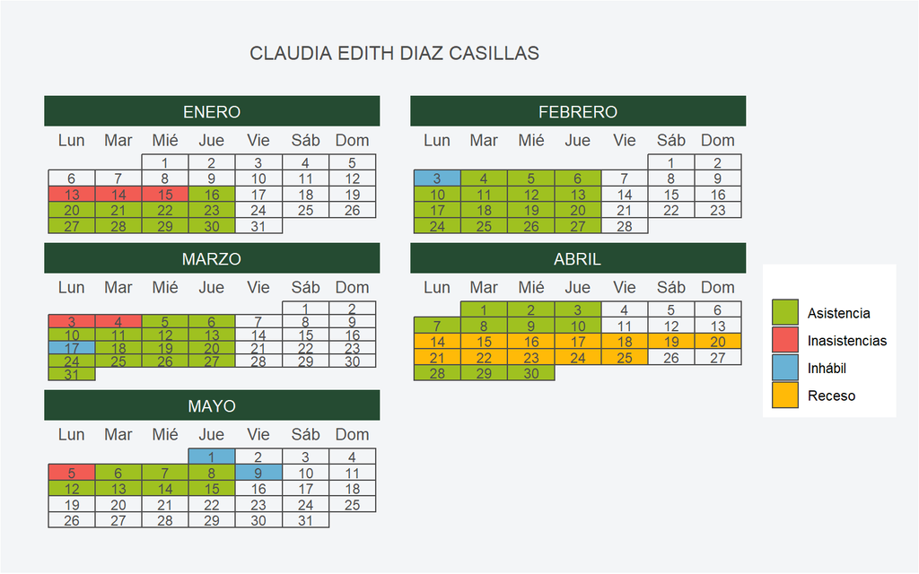

## ENRIQUE ROBERTO PERALTA MAZARIEGO

El profesor Enrique, de acuerdo a los datos tiene clases los días: lunes, martes, miércoles, jueves. De acuerdo a los datos, los días en los cuales el profesor asistió y no asistió se muestran en el siguiente calendario.

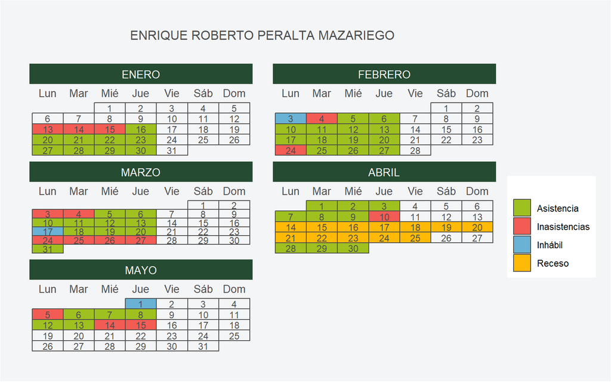

## FABIOLA BETANCOURT OSORIO

La profesora, de acuerdo a los datos tiene clases los días: martes, jueves. De acuerdo a los datos, los días en los cuales la profesora asistió y no asistió se muestran en el siguiente calendario.

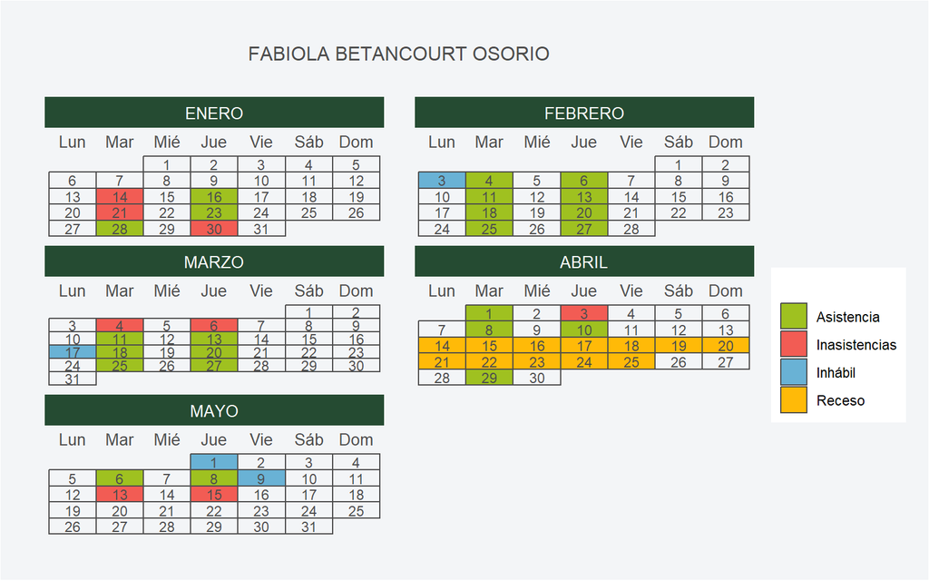

## FRANCISO NAHUAT CHIMAL

El profesor, de acuerdo a los datos tiene clases los días: lunes, miércoles. De acuerdo a los datos, los días en los cuales el profesor asistió y no asistió se muestran en el siguiente calendario.

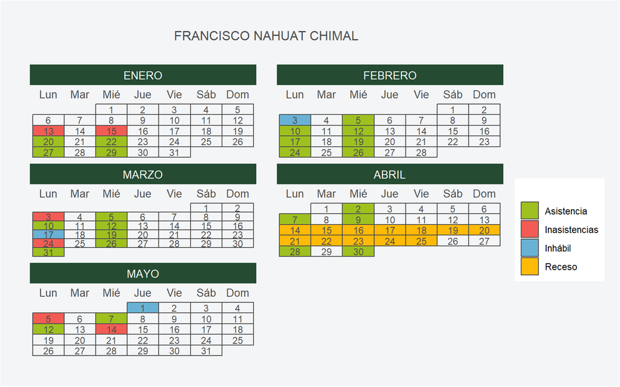

## GERARDO FLORES MARCELO

El profesor, de acuerdo a los datos tiene clases los días: lunes, martes, miércoles, jueves, viernes. De acuerdo a los datos, los días en los cuales el profesor asistió y no asistió se muestran en el siguiente calendario.

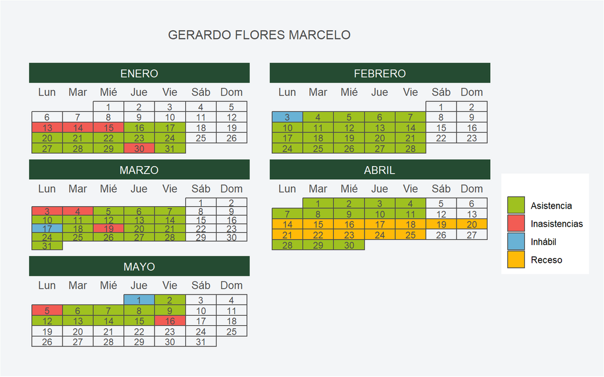

## JORGE LUIS OCOTITLA VAZQUEZ

El profesor, de acuerdo a los datos tiene clases los días: martes, jueves. De acuerdo a los datos, los días en los cuales el profesor asistió y no asistió se muestran en el siguiente calendario.

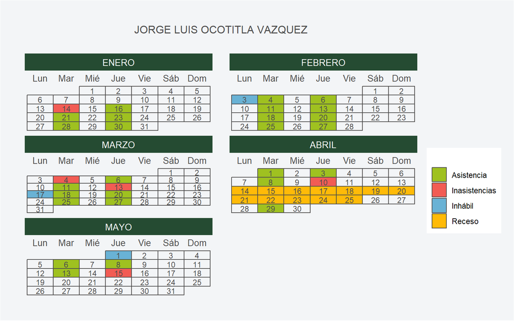

## LILIANA CITALÁN DE LA CRUZ

La profesora, de acuerdo a los datos tiene clases los días: lunes, miércoles, viernes. De acuerdo a los datos, los días en los cuales la profesora asistió y no asistió se muestran en el siguiente calendario.

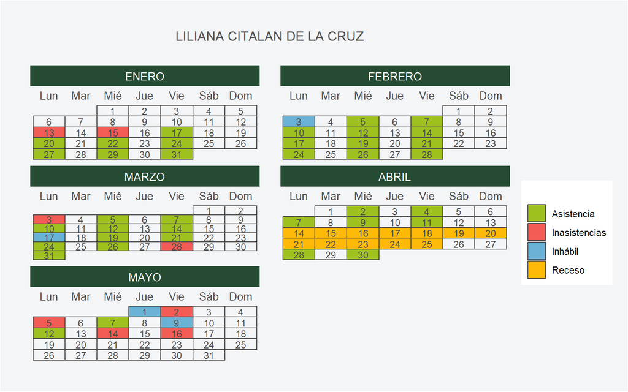

## LUIS BASULTO SOLIS

El profesor, de acuerdo a los datos tiene clases los días: lunes, miércoles. De acuerdo a los datos, los días en los cuales el profesor asistió y no asistió se muestran en el siguiente calendario.

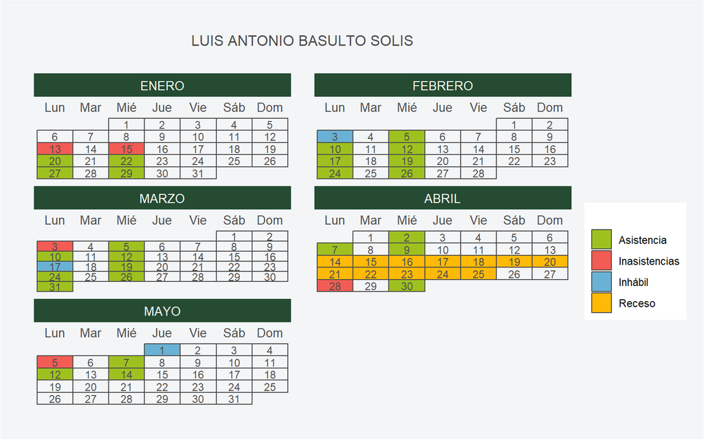

## MARIO LEONARDO FERNÁNDEZ UC

El profesor, de acuerdo a los datos tiene clases los días: lunes, martes, miércoles, jueves. De acuerdo a los datos, los días en los cuales el profesor asistió y no asistió se muestran en el siguiente calendario.

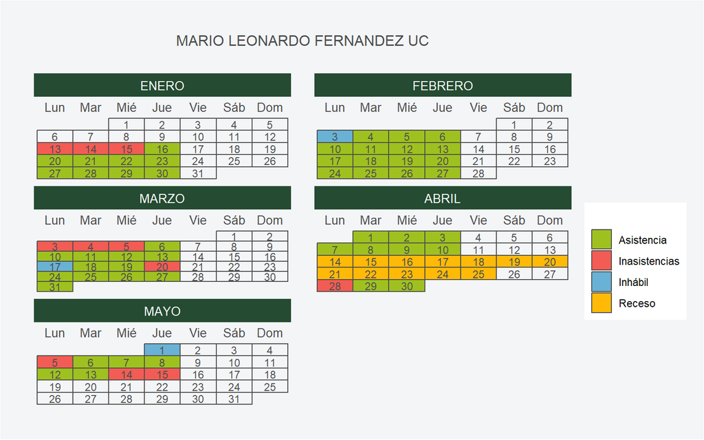

## MELCHOR ERNESTO MUÑOZ DZIB

El profesor, de acuerdo a los datos tiene clases los días: lunes, martes, miércoles, jueves. De acuerdo a los datos, los días en los cuales el profesor asistió y no asistió se muestran en el siguiente calendario.

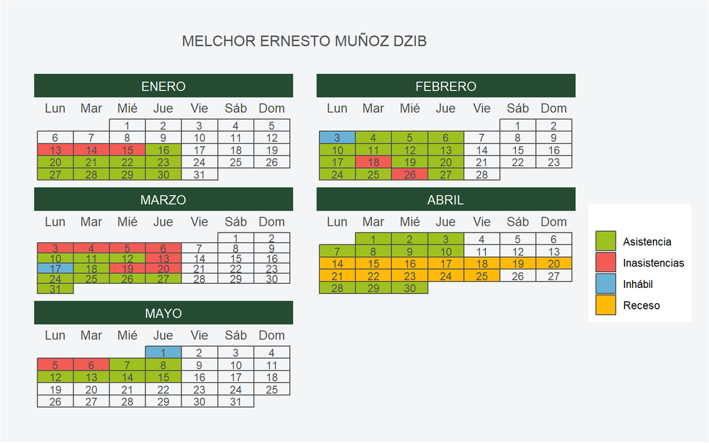

## MIRELLE SOSA CABALLERO

La profesora, de acuerdo a los datos tiene clases los días: martes, jueves. De acuerdo a los datos, los días en los cuales la profesora asistió y no asistió se muestran en el siguiente calendario.

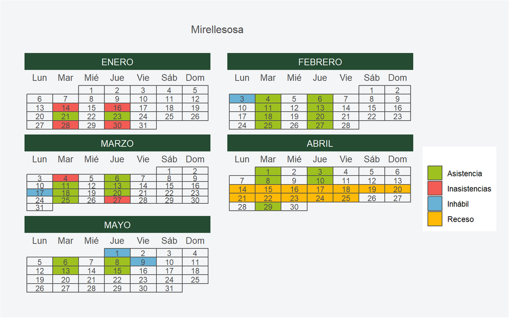

## NESTOR ADOLFO DE LA TORRE SOLIS

El profesor, de acuerdo a los datos tiene clases los días: lunes, miércoles. De acuerdo a los datos, los días en los cuales el profesor asistió y no asistió se muestran en el siguiente calendario.

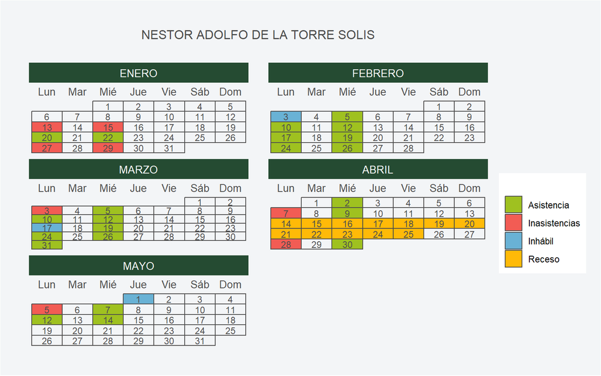

## ABRAHAM RAYMUNDO MENDOZA SANCHEZ

El profesor, de acuerdo a los datos tiene clases los días: lunes, miércoles. De acuerdo a los datos, los días en los cuales el profesor asistió y no asistió se muestran en el siguiente calendario.

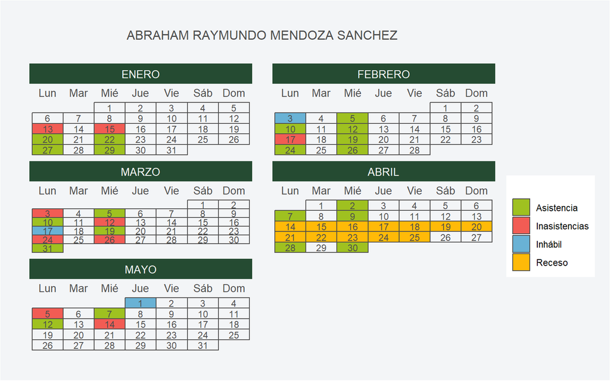

## LUIS CARIDAD NOVELO ALCOCER

El profesor, de acuerdo a los datos tiene clases los días: lunes, martes, miércoles, jueves, viernes. De acuerdo a los datos, los días en los cuales el profesor asistió y no asistió se muestran en el siguiente calendario.

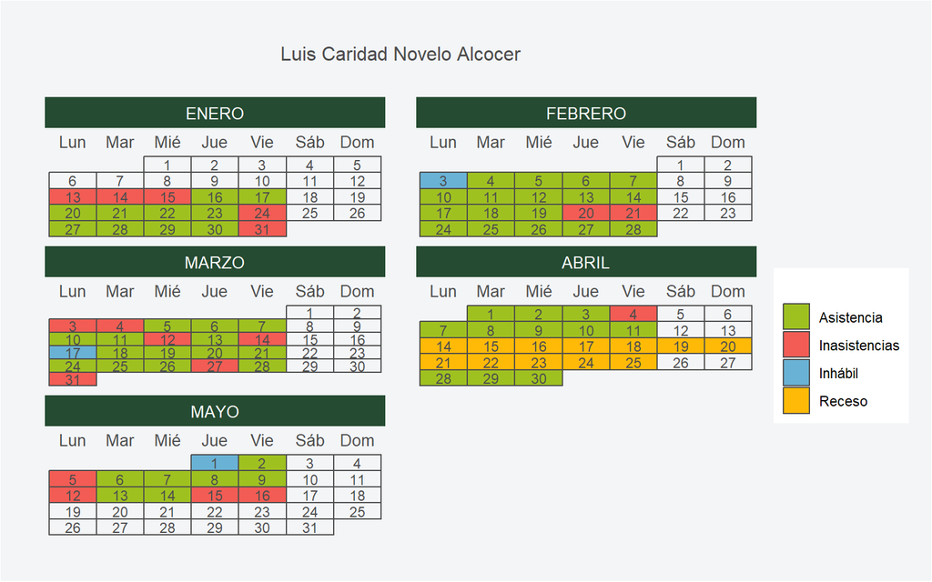

## MARIANA CENICEROS NAVARRO

La profesora, de acuerdo a los datos tiene clases los días: lunes, martes, miércoles, jueves, viernes. De acuerdo a los datos, los días en los cuales la profesora asistió y no asistió se muestran en el siguiente calendario.

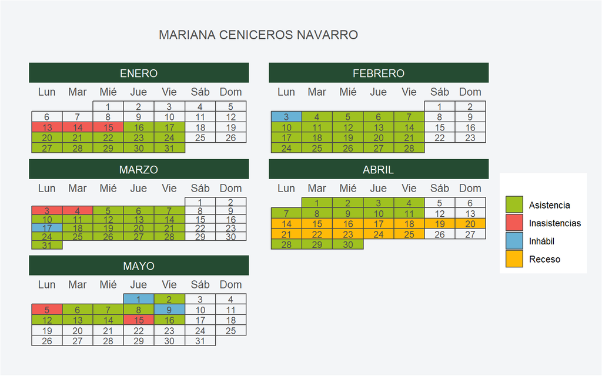

## ALFREDO CORTES SANTOS

El profesor, de acuerdo a los datos tiene clases los días: lunes, martes, miércoles, jueves. De acuerdo a los datos, los días en los cuales el profesor asistió y no asistió se muestran en el siguiente calendario.

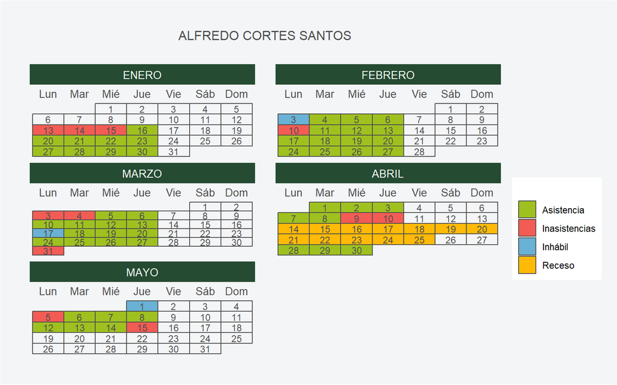

## ANGEL PRIETO PAMEROS

El profesor, de acuerdo a los datos tiene clases los días: martes, jueves, sábado. De acuerdo a los datos, los días en los cuales el profesor asistió y no asistió se muestran en el siguiente calendario.

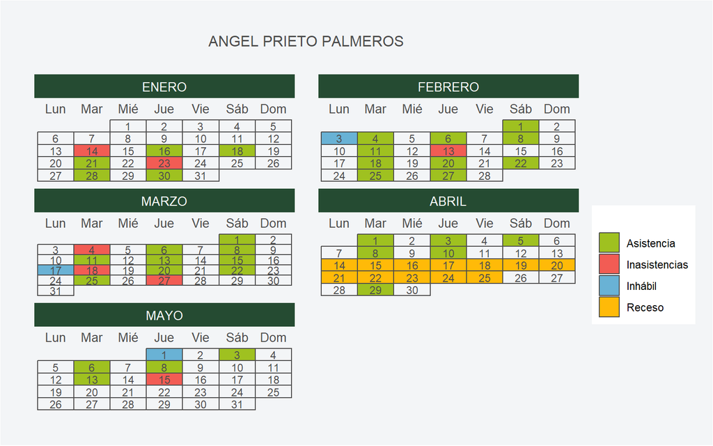

## MILDRED PAULINA ÁLVAREZ MARTAGÓN

La profesora, de acuerdo a los datos tiene clases los días: lunes, miércoles. De acuerdo a los datos, los días en los cuales la profesora asistió y no asistió se muestran en el siguiente calendario.

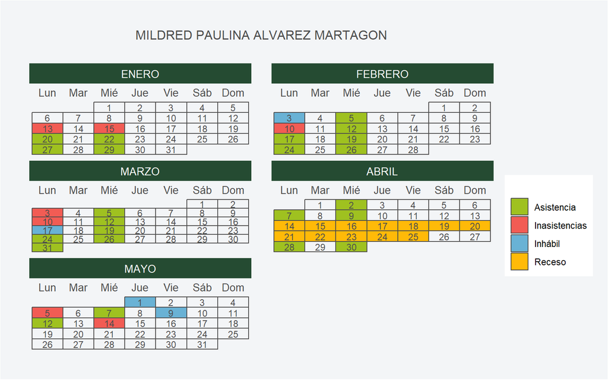

## FRANK ALVIN LORIA MAYEN

El profesor, de acuerdo a los datos tiene clases los días: lunes, martes, miércoles, jueves, viernes. De acuerdo a los datos, los días en los cuales el profesor asistió y no asistió se muestran en el siguiente calendario.

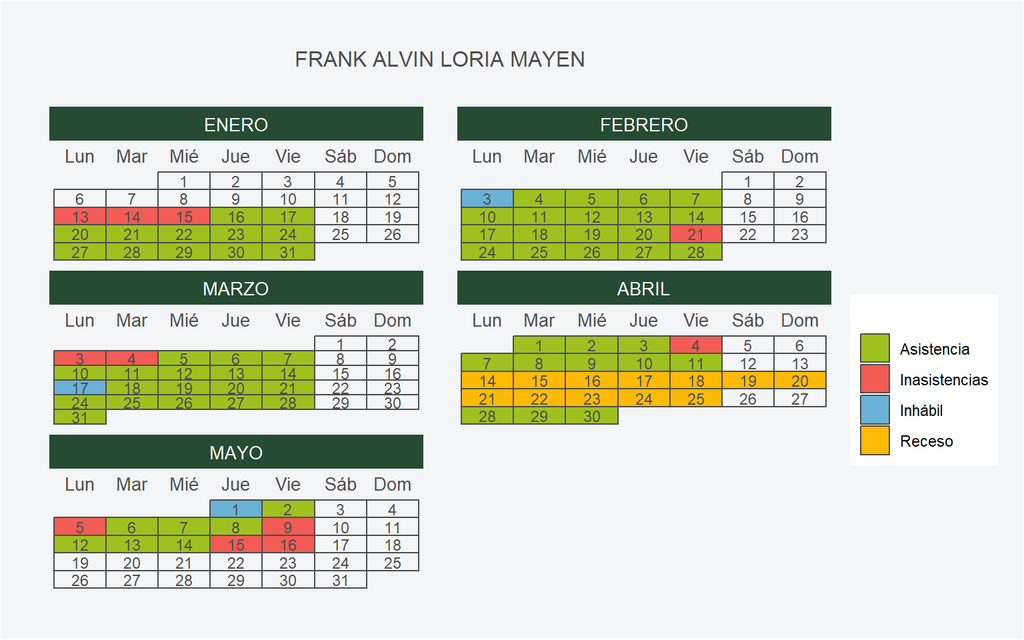